# Time series part1

# Time series

## introduction

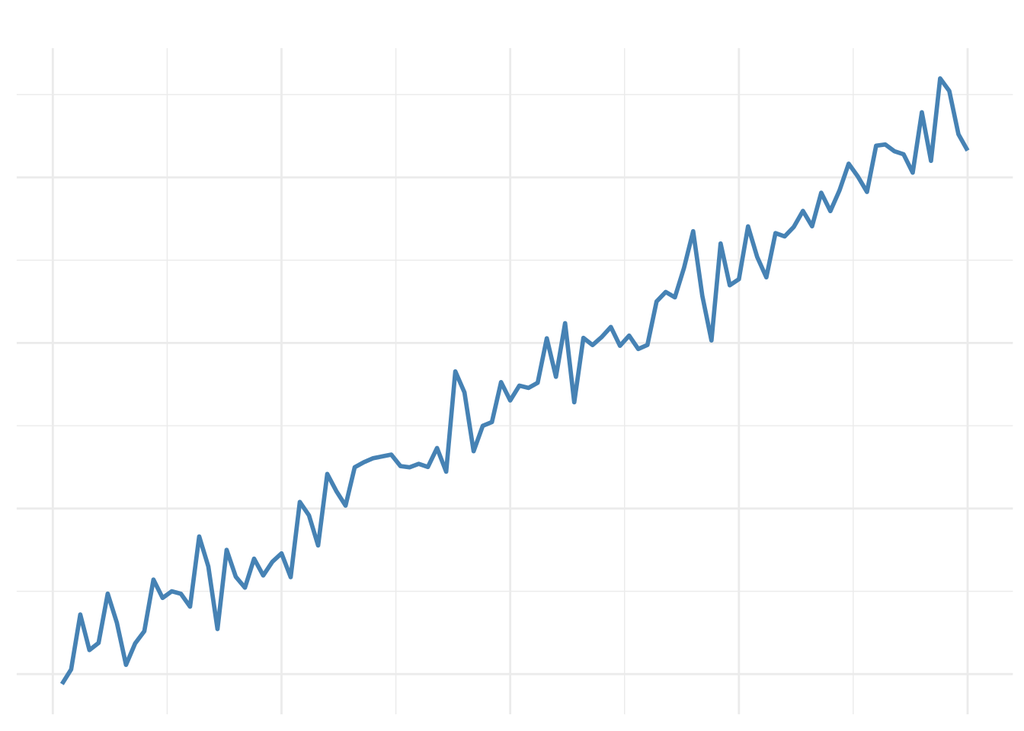

```r
set.seed(123)

# Trend
trend <- 1:100 + rnorm(100, 0, 5)
pi=22/7
# Seasonality
time <- 1:100
seasonal <- 10 * sin(2 * pi * time / 12) + rnorm(100, 0, 2)

# Noise
noise <- rnorm(100)

# Trend + Seasonality
trend_season <- 1:100 + 10 * sin(2 * pi * time / 12) + rnorm(100, 0, 5)

# Random Walk
random_walk <- cumsum(rnorm(100))

# Plot function
library(ggplot2)
plot_ts <- function(y, title = "") {
  ggplot(data.frame(x = 1:length(y), y = y), aes(x, y)) +
    geom_line(color = "steelblue", linewidth = 1) +
    theme_minimal() +
    theme(axis.title = element_blank(),
          axis.text = element_blank(),
          axis.ticks = element_blank(),
          plot.title = element_text(hjust = 0.5)) +
    ggtitle(title)
}

plot_ts(trend)
```

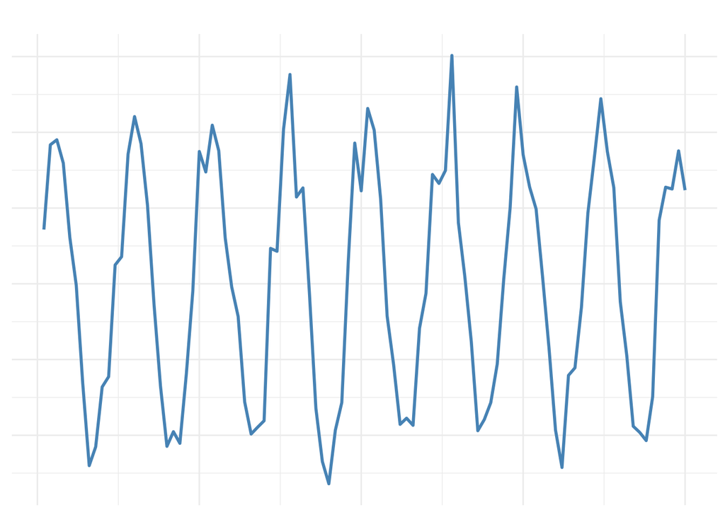

```r
plot_ts(seasonal)
```

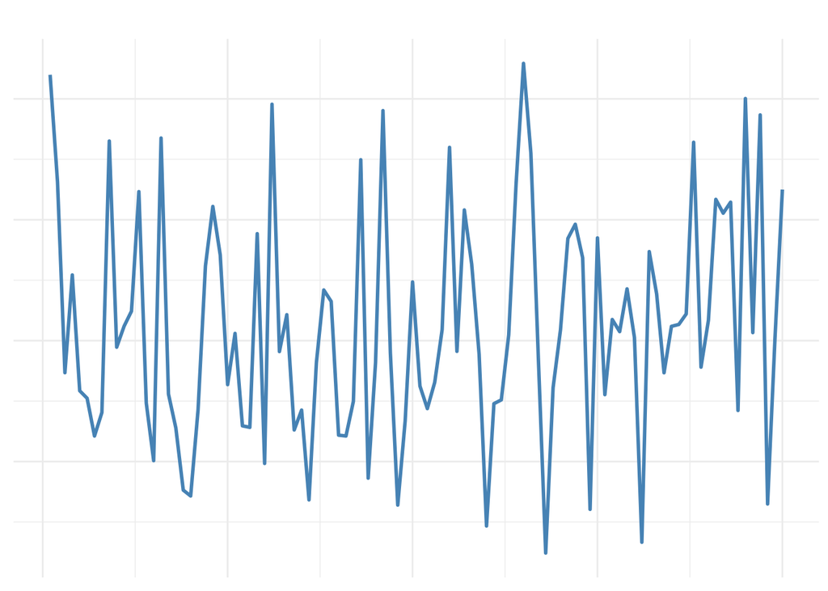

```r
plot_ts(noise)
```

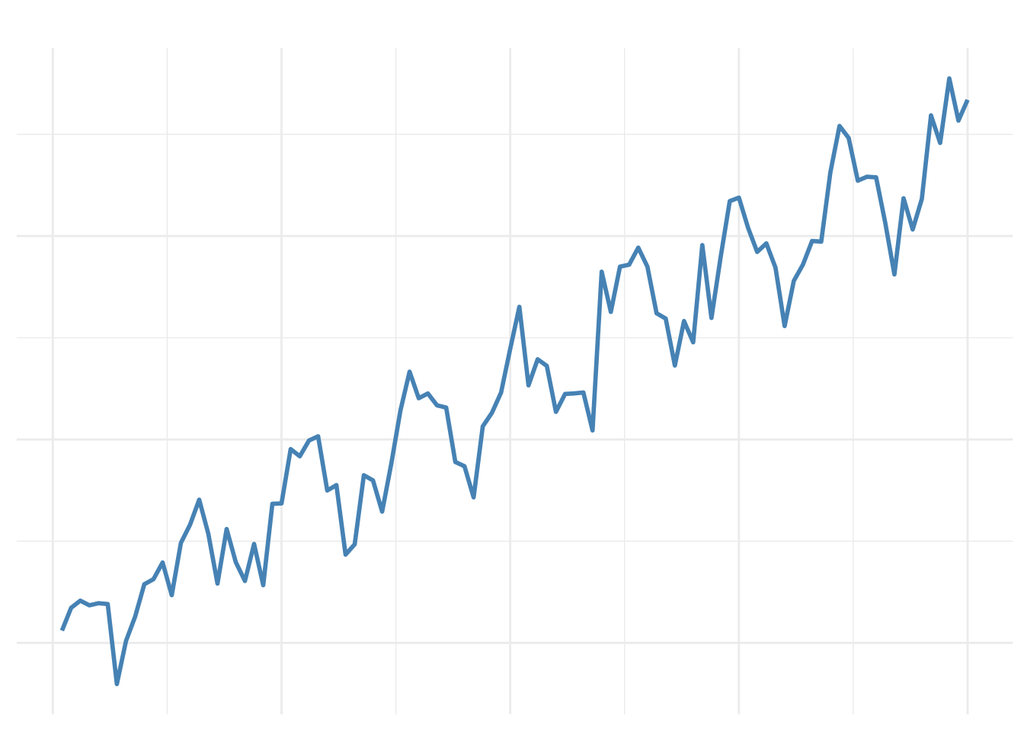

```r
plot_ts(trend_season)
```

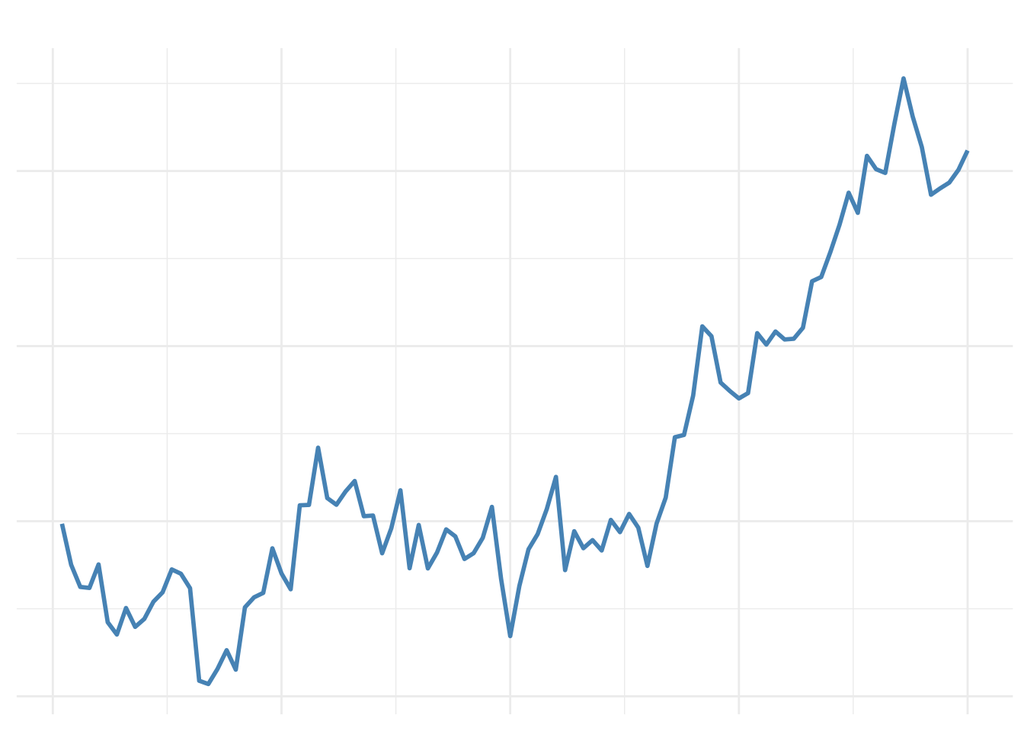

```r
plot_ts(random_walk)
```

Trend: The overall motion of the series. It may be consistently increasing overtime, decreasing overtime or a combination of both.

seasonality: Any regular seasonal pattern in the series. We expect ice cream sales to be higher in the summer months and lower in winter months

Residual/ Remainder: This is the bit that is left over after we take into account the trend and seasonality. It can also be thought of as a statistical noise.

## Auto regressive (AR) model

- uses past values to predict future
- order of AR model denoted by p AR(1), AR(2), etc
- p=no: of lagged observations AR(p) is defined as

$$y_t=c + \phi y_{t-1} + \phi y_{t-2}+
\phi y_{t-3}+ ..... + \epsilon_t$$

$\epsilon_t$ is white noise.  
c is the constant term.  
$\phi$ is the parameter of the model.  
$y_{t-1}$, $y_{t-2}$ are the past values.

$$AR(2)=c+ \phi_1 y_{t-1} + \phi_2
y_{t-2}$$
$$AR(1)=c+\phi_1
y_{t-1}$$

## Moving Average (MA) model

- uses the past error terms (residual)
- order of the MA(q)
- q= no of lagged error terms. which is different from moving average smoothing technique

$$y_t=\epsilon+\theta_1
\epsilon_{t-1}+\theta_2 \epsilon_{t-2}.....$$

https://www.icicidirect.com/futures-and-options/articles/what-is-moving-averages-and-how-does-it-help-in-technical-analysis

$\theta_1=?$  
$\theta_2=?$

[output not shown]

## AutoRegressive Moving Average (ARMA)

- COMBINES AR & MA model for forecasting
- captures both temporal dependencies and error terms
- order (p,q)
- ARMA(p,q)

$$=c+ \phi_1 y_{t-1} + \phi_2 y_{t-2}
c+\phi_1 y_{t-1}+...........+\theta_1 \epsilon_{t-1}+\theta_2
\epsilon_{t-2}+.....$$

## ARIMA

- In this model I is added which is “INTEGRATED”.
- difference order
- ARIMA(p,d,q)
- p (from AR model)
- d (difference),
- q (from MA model))

  $$\Delta y_t= \phi_1 \Delta y_{t-1}+ \phi_2 \Delta y_{t-2}+..... +$$

  remaning terms as like ARMA

## SARIMA

- S stands for Seasonality
- so it is Seasonal ARIMA model
- SARIMA (p,d,q) (P,D,Q) M
- (p,d,q) order of ARIMA
- (P,D,Q) order of seasonal part
- m period

```r
a<-scan("Attendance.txt")
ax<- ts(a)
af<-arima(ax,order=c(0,2,1))
af
```

```
##
## Call:
## arima(x = ax, order = c(0, 2, 1))
##
## Coefficients:
##           ma1
##       -1.0000
## s.e.   0.0925
##
## sigma^2 estimated as 252.7:  log likelihood = -114.66,  aic = 233.32
```

```r
library("forecast")
```

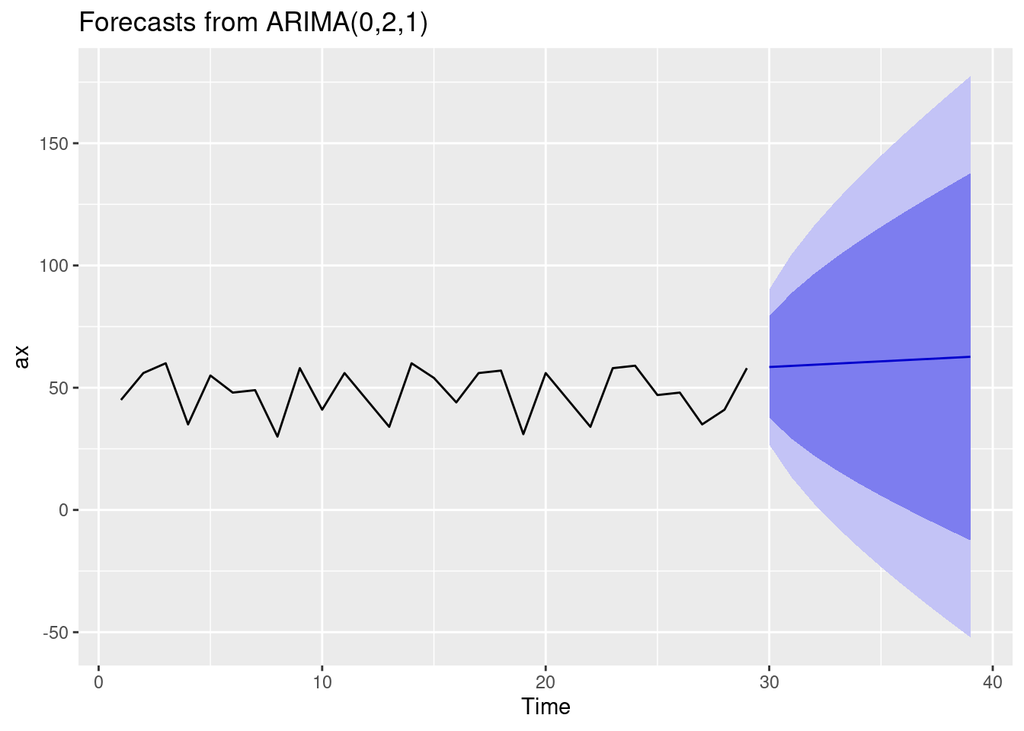

```r
f<-forecast(af)
autoplot(f)
```

## stationarity vs. non-stationarity

constant variance through time, constant mean through time.

“Imagine you’re standing on a flat treadmill — you keep walking, but your view doesn’t change much over time. That’s a stationary process — things vary, but their average and spread stay constant.

Now imagine walking uphill — even if your pace is steady, your elevation keeps increasing. That’s non-stationary — the data has a trend.”

You can also compare to:

Weather vs. climate: daily temperature fluctuates (stationary around a mean), but long-term warming (non-stationary).

Student grades: if the class average stays the same every semester → stationary; if it keeps improving over years → non-stationary.

| Concept | What it Means | How to Spot It |
| --- | --- | --- |
| **Stationary** | Mean, variance, and autocovariance do **not change over time** | Data fluctuates around a constant level |
| **Non-stationary** | Mean or variance **changes over time** | Upward/downward trend, changing spread, or seasonality |

### Use AirPassengers data (non-stationary)

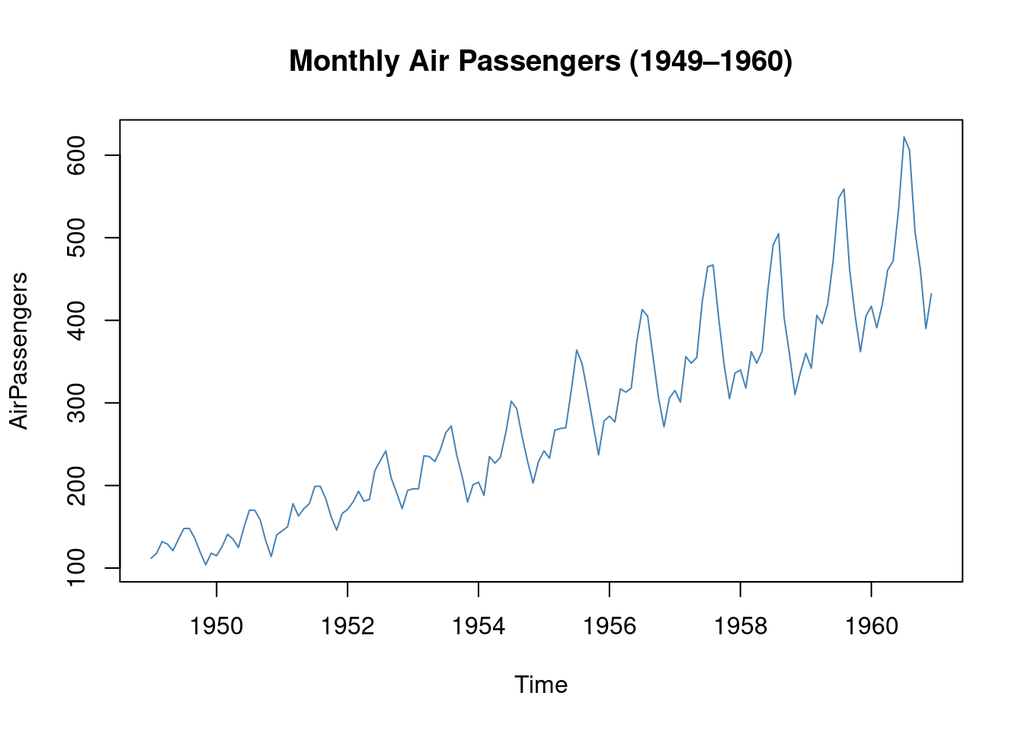

```r
data("AirPassengers")
plot(AirPassengers, main="Monthly Air Passengers (1949–1960)", col="steelblue")
```

- Do you see a trend? (Upward)
- Is the variability constant? (No — it grows with time)

### Check stationarity formally with ADF test

Augmented Dickey–Fuller test (ADF)

```r
library(tseries)
adf.test(AirPassengers,k=7)
```

```
##
##  Augmented Dickey-Fuller Test
##
## data:  AirPassengers
## Dickey-Fuller = -7.3689, Lag order = 7, p-value = 0.01
## alternative hypothesis: stationary
```

```r
adf.test(diff(AirPassengers))
```

```
##
##  Augmented Dickey-Fuller Test
##
## data:  diff(AirPassengers)
## Dickey-Fuller = -7.0177, Lag order = 5, p-value = 0.01
## alternative hypothesis: stationary
```

Make it stationary

Log-transform to stabilize variance:

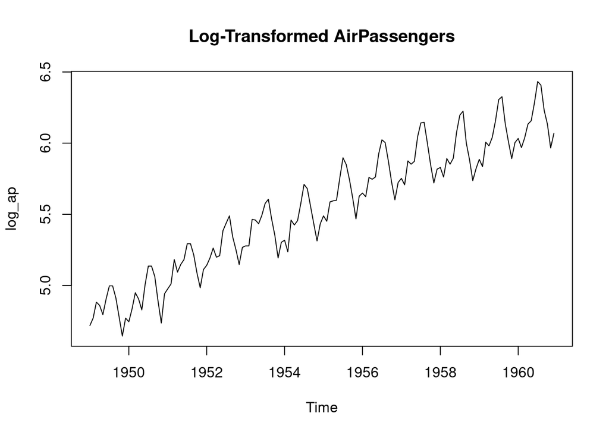

```r
log_ap <- log(AirPassengers)
plot(log_ap, main="Log-Transformed AirPassengers")
```

Difference to remove trend:

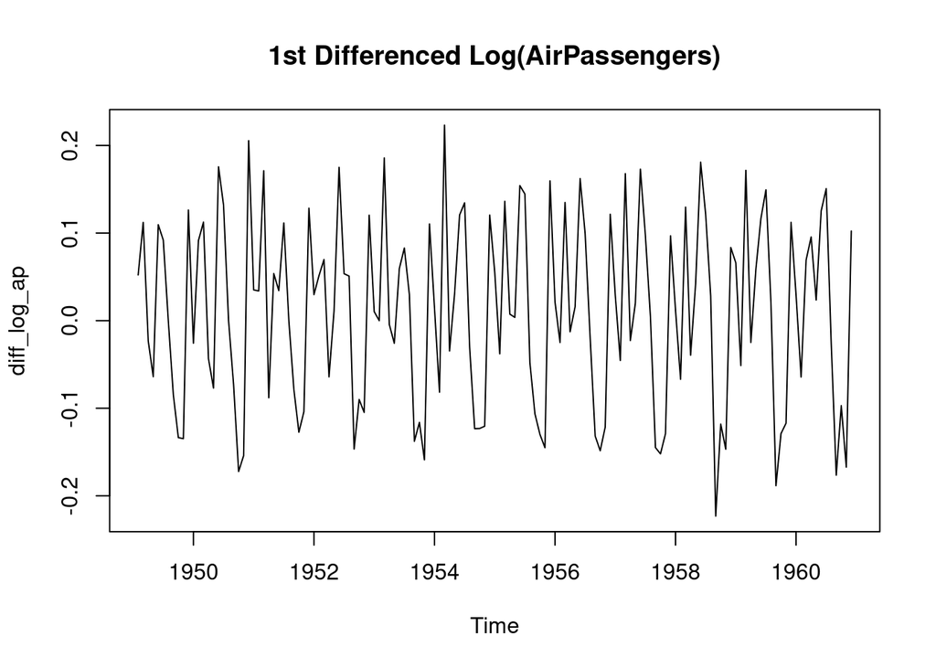

```r
diff_log_ap <- diff(log_ap)
plot(diff_log_ap, main="1st Differenced Log(AirPassengers)")
```

```r
adf.test(diff_log_ap)
```

```
##
##  Augmented Dickey-Fuller Test
##
## data:  diff_log_ap
## Dickey-Fuller = -6.4313, Lag order = 5, p-value = 0.01
## alternative hypothesis: stationary
```

In Augmented Dickey–Fuller (ADF) test:

Null hypothesis (H₀): the series is non-stationary (has a unit root).

Alternative hypothesis (H₁): the series is stationary.

So:

High p-value (> 0.05) → Fail to reject H₀ → likely non-stationary.

Low p-value (< 0.05) → Reject H₀ → likely stationary.

| Concept | Key Idea | R Example |
| --- | --- | --- |
| **Stationary** | Mean, variance constant over time | `rnorm(100)` |
| **Non-stationary** | Trend, seasonality, or changing variance | `AirPassengers` |
| **Why it matters** | Many models (ARIMA, ETS) assume stationarity |  |
| **How to fix it** | Differencing, detrending, logging |  |

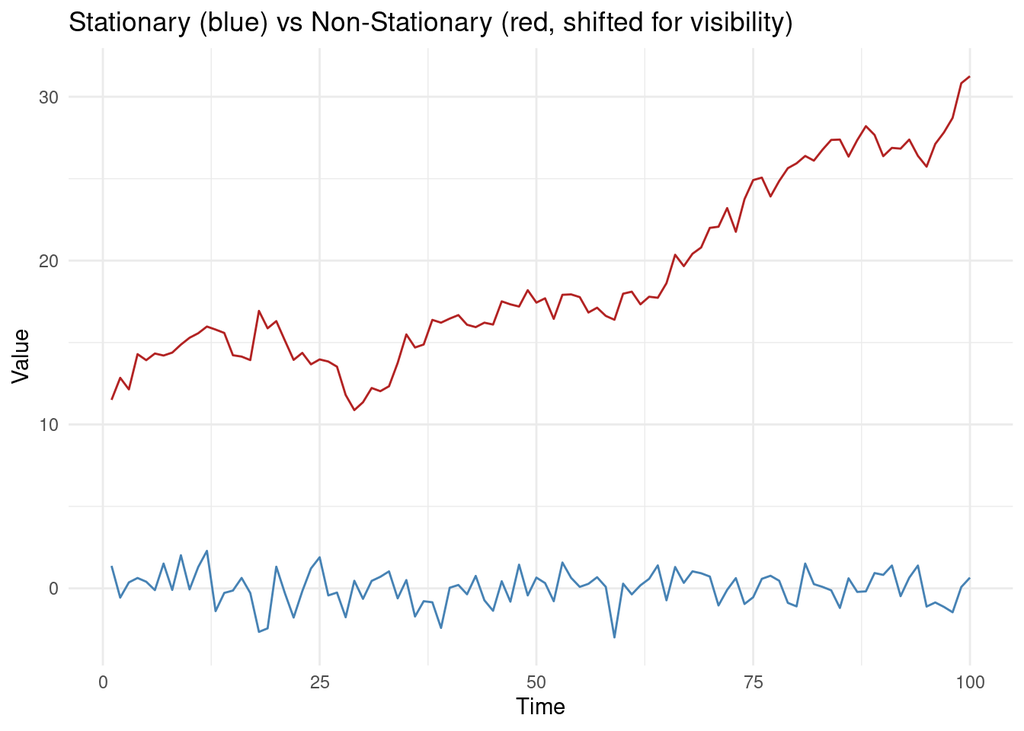

```r
library(ggplot2)
set.seed(42)
time <- 1:100

# Stationary (white noise)
stationary <- rnorm(100, mean = 0, sd = 1)

# Non-stationary (with trend)
nonstationary <- cumsum(rnorm(100, mean = 0.3, sd = 1))

# Plot
df <- data.frame(time, stationary, nonstationary)

ggplot(df, aes(time)) +
  geom_line(aes(y = stationary), color = "steelblue") +
  geom_line(aes(y = nonstationary + 10), color = "firebrick") +
  theme_minimal() +
  labs(title = "Stationary (blue) vs Non-Stationary (red, shifted for visibility)",
       x = "Time", y = "Value")
```

```r
#install.packages("forecast")
library(forecast)
data("AirPassengers")
class(AirPassengers)
```

```
## [1] "ts"
```

```r
start(AirPassengers)
```

```
## [1] 1949    1
```

```r
end(AirPassengers)
```

```
## [1] 1960   12
```

```r
frequency(AirPassengers)
```

```
## [1] 12
```

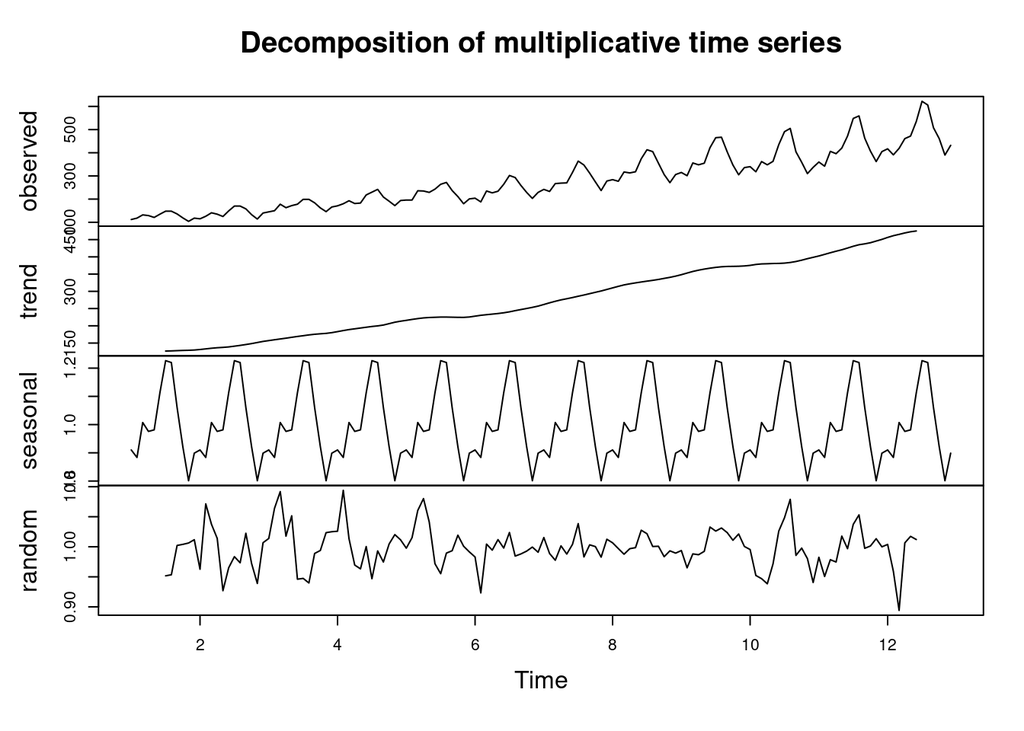

```r
tsdata<-ts(AirPassengers,frequency = 12)
ddata<-decompose(tsdata,"multiplicative")
plot(ddata)
```

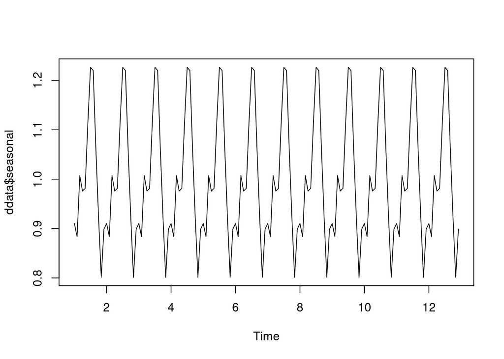

```r
plot(ddata$seasonal)
```

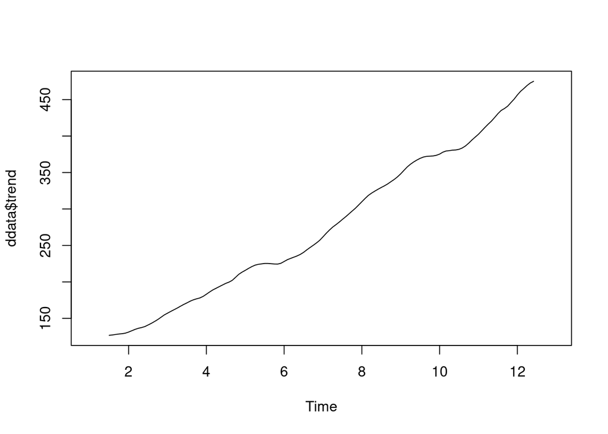

```r
plot(ddata$trend)
```

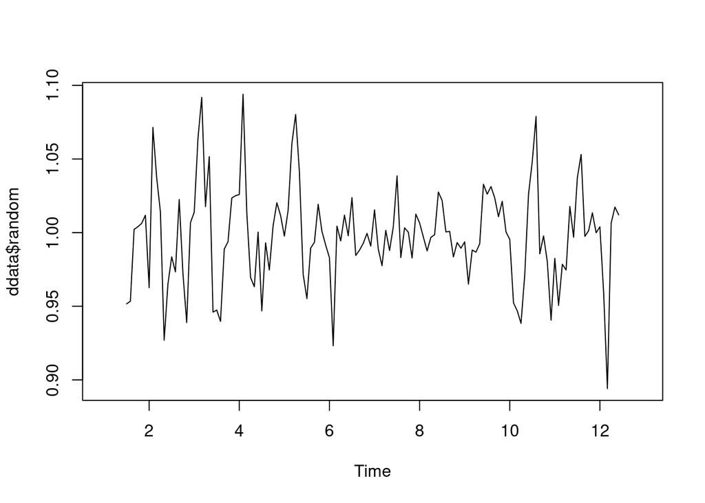

```r
plot(ddata$random)
```

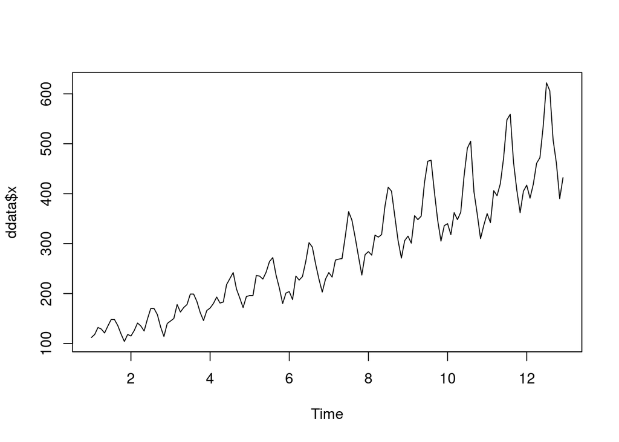

```r
plot(ddata$x)
```

Stationarity of Time Series Data using R https://www.geeksforgeeks.org/r-machine-learning/stationarity-of-time-series-data-using-r/

```r
time(AirPassengers)
```

```
##           Jan      Feb      Mar      Apr      May      Jun      Jul      Aug
## 1949 1949.000 1949.083 1949.167 1949.250 1949.333 1949.417 1949.500 1949.583
## 1950 1950.000 1950.083 1950.167 1950.250 1950.333 1950.417 1950.500 1950.583
## 1951 1951.000 1951.083 1951.167 1951.250 1951.333 1951.417 1951.500 1951.583
## 1952 1952.000 1952.083 1952.167 1952.250 1952.333 1952.417 1952.500 1952.583
## 1953 1953.000 1953.083 1953.167 1953.250 1953.333 1953.417 1953.500 1953.583
## 1954 1954.000 1954.083 1954.167 1954.250 1954.333 1954.417 1954.500 1954.583
## 1955 1955.000 1955.083 1955.167 1955.250 1955.333 1955.417 1955.500 1955.583
## 1956 1956.000 1956.083 1956.167 1956.250 1956.333 1956.417 1956.500 1956.583
## 1957 1957.000 1957.083 1957.167 1957.250 1957.333 1957.417 1957.500 1957.583
## 1958 1958.000 1958.083 1958.167 1958.250 1958.333 1958.417 1958.500 1958.583
## 1959 1959.000 1959.083 1959.167 1959.250 1959.333 1959.417 1959.500 1959.583
## 1960 1960.000 1960.083 1960.167 1960.250 1960.333 1960.417 1960.500 1960.583
##           Sep      Oct      Nov      Dec
## 1949 1949.667 1949.750 1949.833 1949.917
## 1950 1950.667 1950.750 1950.833 1950.917
## 1951 1951.667 1951.750 1951.833 1951.917
## 1952 1952.667 1952.750 1952.833 1952.917
## 1953 1953.667 1953.750 1953.833 1953.917
## 1954 1954.667 1954.750 1954.833 1954.917
## 1955 1955.667 1955.750 1955.833 1955.917
## 1956 1956.667 1956.750 1956.833 1956.917
## 1957 1957.667 1957.750 1957.833 1957.917
## 1958 1958.667 1958.750 1958.833 1958.917
## 1959 1959.667 1959.750 1959.833 1959.917
## 1960 1960.667 1960.750 1960.833 1960.917
```

```r
print(AirPassengers)
```

```
##      Jan Feb Mar Apr May Jun Jul Aug Sep Oct Nov Dec
## 1949 112 118 132 129 121 135 148 148 136 119 104 118
## 1950 115 126 141 135 125 149 170 170 158 133 114 140
## 1951 145 150 178 163 172 178 199 199 184 162 146 166
## 1952 171 180 193 181 183 218 230 242 209 191 172 194
## 1953 196 196 236 235 229 243 264 272 237 211 180 201
## 1954 204 188 235 227 234 264 302 293 259 229 203 229
## 1955 242 233 267 269 270 315 364 347 312 274 237 278
## 1956 284 277 317 313 318 374 413 405 355 306 271 306
## 1957 315 301 356 348 355 422 465 467 404 347 305 336
## 1958 340 318 362 348 363 435 491 505 404 359 310 337
## 1959 360 342 406 396 420 472 548 559 463 407 362 405
## 1960 417 391 419 461 472 535 622 606 508 461 390 432
```

```r
cycle(AirPassengers)
```

```
##      Jan Feb Mar Apr May Jun Jul Aug Sep Oct Nov Dec
## 1949   1   2   3   4   5   6   7   8   9  10  11  12
## 1950   1   2   3   4   5   6   7   8   9  10  11  12
## 1951   1   2   3   4   5   6   7   8   9  10  11  12
## 1952   1   2   3   4   5   6   7   8   9  10  11  12
## 1953   1   2   3   4   5   6   7   8   9  10  11  12
## 1954   1   2   3   4   5   6   7   8   9  10  11  12
## 1955   1   2   3   4   5   6   7   8   9  10  11  12
## 1956   1   2   3   4   5   6   7   8   9  10  11  12
## 1957   1   2   3   4   5   6   7   8   9  10  11  12
## 1958   1   2   3   4   5   6   7   8   9  10  11  12
## 1959   1   2   3   4   5   6   7   8   9  10  11  12
## 1960   1   2   3   4   5   6   7   8   9  10  11  12
```

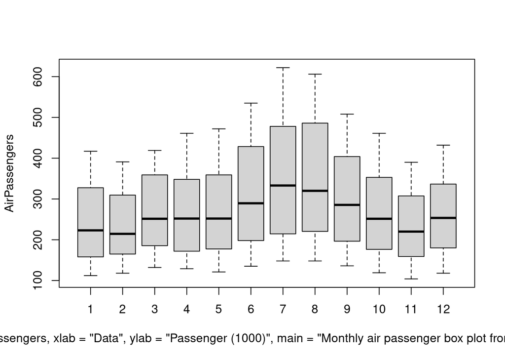

```r
boxplot(AirPassengers~cycle(AirPassengers,xlab="Data", ylab="Passenger (1000)",main="Monthly air passenger box plot from 1949 to 1901"))
```

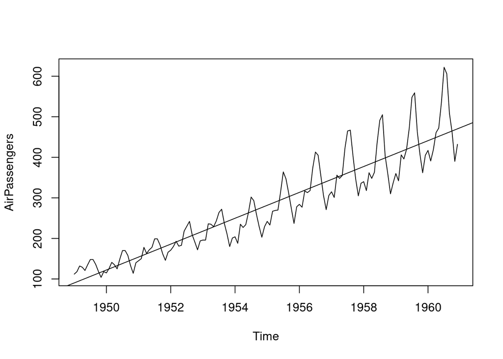

```r
plot(AirPassengers)
abline(reg=lm(AirPassengers~time(AirPassengers)))
```

```r
mymodel<-auto.arima(AirPassengers)
mymodel
```

```
## Series: AirPassengers
## ARIMA(2,1,1)(0,1,0)[12]
##
## Coefficients:
##          ar1     ar2      ma1
##       0.5960  0.2143  -0.9819
## s.e.  0.0888  0.0880   0.0292
##
## sigma^2 = 132.3:  log likelihood = -504.92
## AIC=1017.85   AICc=1018.17   BIC=1029.35
```

```r
auto.arima(AirPassengers,ic="aic",trace=TRUE)
```

```
##
##  ARIMA(2,1,2)(1,1,1)[12]                    : Inf
##  ARIMA(0,1,0)(0,1,0)[12]                    : 1031.508
##  ARIMA(1,1,0)(1,1,0)[12]                    : 1020.393
##  ARIMA(0,1,1)(0,1,1)[12]                    : 1021.003
##  ARIMA(1,1,0)(0,1,0)[12]                    : 1020.394
##  ARIMA(1,1,0)(2,1,0)[12]                    : 1019.24
##  ARIMA(1,1,0)(2,1,1)[12]                    : Inf
##  ARIMA(1,1,0)(1,1,1)[12]                    : Inf
##  ARIMA(0,1,0)(2,1,0)[12]                    : 1032.12
##  ARIMA(2,1,0)(2,1,0)[12]                    : 1021.12
##  ARIMA(1,1,1)(2,1,0)[12]                    : 1021.033
##  ARIMA(0,1,1)(2,1,0)[12]                    : 1019.178
##  ARIMA(0,1,1)(1,1,0)[12]                    : 1020.425
##  ARIMA(0,1,1)(2,1,1)[12]                    : Inf
##  ARIMA(0,1,1)(1,1,1)[12]                    : Inf
##  ARIMA(0,1,2)(2,1,0)[12]                    : 1021.148
##  ARIMA(1,1,2)(2,1,0)[12]                    : 1022.805
##
##  Best model: ARIMA(0,1,1)(2,1,0)[12]
```

```
## Series: AirPassengers
## ARIMA(0,1,1)(2,1,0)[12]
##
## Coefficients:
##           ma1     sar1    sar2
##       -0.3634  -0.1239  0.1911
## s.e.   0.0899   0.0934  0.1036
##
## sigma^2 = 133.5:  log likelihood = -505.59
## AIC=1019.18   AICc=1019.5   BIC=1030.68
```

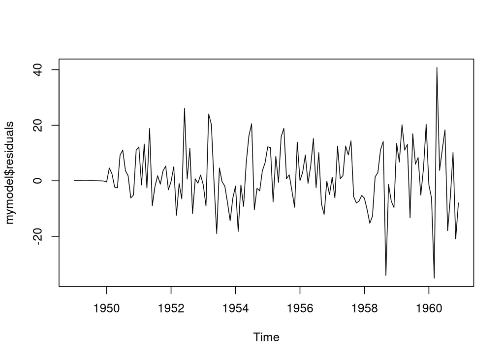

```r
library(tseries)
#adf.test(mymodel)
plot.ts(mymodel$residuals)
```

### Autocorrelation Function (ACF)

The ACF plots the correlation of the time series with itself at different lags. This helps in identifying patterns such as seasonality, trends, and the persistence of values over time.

- **Lag 1:** Correlation between observations at time t and t−1
- **Lag 2:** Correlation between observations at time t and t−2
- And so on…

### Partial Autocorrelation

Partial autocorrelation measures the correlation between observations at two time points, accounting for the values of the observations at all shorter lags. This helps isolate the direct relationship between observations at different lags, removing the influence of intermediary observations.

Autocorrelation and partial autocorrelation helps us detect certain features in our series to enable us to choose the most optimal forecast model for our data.

Autocorrelation is just the correlation of the data with itself.